# Eurofer Properties Database

- Abstract
- Introduction
- Section 1: Manufacturing
  - 1.1. Composition
  - 1.2. Material Processing Routes
  - 1.3. Heat Treatment
  - 1.4. Microstructure
  - 1.5. Manufacturers & Product Forms
  - 1.6. Material Tags
- Section 2: Thermo-physical Properties
  - 2.1. Density
  - 2.2. Thermal Diffusivity
  - 2.3. Specific Heat
  - 2.4. Thermal Conductivity
  - 2.5. Coefficient of Thermal Expansion
  - 2.6. Thermal Emissivity
  - 2.7. Electrical Resistivity
  - 2.8. Magnetic Properties
  - 2.9. Elastic Properties
- Section 3: Mechanical Properties

## Abstract

We present a comprehensive database for the ferritic-martensitic steel Eurofer97. The database is intended to assist in the mechanical design of components manufactured from reduced activation 9 Cr steels (e.g. Eurofer97), in particular, in a fusion reactor power source. The database is classified into three main categories: (1) fabrication and microstructure, (2) thermophysical properties, and (3) mechanical properties. The effects of irradiation (both neutron and ion) on the properties of Eurofer are also discussed. Data for each property is collected from various sources available in the public domain. The sources of data are given together with links to the original publication for verification or corrections. Various functional forms are developed to describe the properties of Eurofer97 as a function of temperature, and if available, as a function of the irradiation dose.

## Section 1: Manufacturing

### 1.1. Composition

| Specification | Producer analysis, heat 83699/83698 (Ø100 mm/14 mm) | IMF analysis, heat 83698, 1.5 mm plate | CEA analysis, 3 heats, 5 sizes |  |
| --- | --- | --- | --- | --- |
| Cr | 8.50-9.50 | 8.87/8.82 | 9.21 | 8.68-9.04 |
| C | 0.09-0.12 | 0.12/0.11 | 0.104 | 0.092-0.117 |
| Mn | 0.20-0.60 | 0.42/0.47 | 0.502 | 0.41-0.50 |
| V | 0.15-0.25 | 0.19/0.20 | 0.204 | 0.17-0.19 |
| W | 1.0-1.2 | 1.10/1.09 | 1.148 | 1.03-1.26 |
| Ta | 0.05-0.09 | 0.14/0.13 | 0.14 | 0.10-0.15 |
| N2 | 0.015-0.045 | 0.018/0.020 | 0.0234 | 0.018-0.0226 |
| O2 | max. 0.01 | 0.0013/0.0010 | <0.001 | 0.0005-0.0011 |
| P | max. 0.005 | 0.004/0.005 | <0.04 | 0.011-0.013 |
| S | max. 0.005 | 0.003/0.004 | 0.004 | <0.003 |
| B | max. 0.001*) | <0.0005/0.001 | <0.01 | <0.001 |
| Ti | max. 0.01 | 0.008/0.005 | 0.004 | 0.001-0.005 |
| Nb | max. 0.001*) | <0.0010/0.0016 | 12 ppm | <20 ppm |
| Mo | max. 0.005*) | <0.0010/0.0010 | <8 | <20-100 |
| Ni | max. 0.005*) | <0.007/0.0200 | 214 | 400-600 |
| Cu | max. 0.005*) | 0.022/0.0016 | 35 | 30-400 |
| Al | max. 0.01*) | 0.008/0.009 | 51 | 30-40 |
| Si | max. 0.05*) | 0.07/0.04 | 430 | 300-600 |
| Co | max. 0.005*) | 0.004/0.006 | 67 | 80-200 |
| As+Sn+Sb+Zr | max. 0.05 | <0.015/0.015 |  | <65-145 |

### 1.2. Material Processing Routes

#### 1.2.1. Melting and Casting Route

1. **Raw Material Selection and Alloying**
   - **Iron (Fe)** is the primary component of RAFM steels.
   - **Alloying Elements:** Specific elements are added to achieve the desired properties. These typically include:
     - **Chromium (Cr):** Typically around 8-12% to provide corrosion resistance and stabilize the ferritic structure.
     - **Tungsten (W):** Often added to improve high-temperature strength and radiation resistance.
     - **Molybdenum (Mo):** Sometimes used for strength and corrosion resistance.
     - **Vanadium (V):** Added to enhance strength through precipitation hardening.
     - **Carbon (C):** Present in low amounts (~0.1%) to form carbides, which strengthen the steel.
     - **Other elements like Ta (Tantalum) or Nb (Niobium):** Used for further stabilization and to refine grain structure.
   1. **Melting and Casting**
   - **Melting:** The raw materials are melted together in a furnace, often an electric arc furnace, to form a homogenous liquid alloy.
   - **Deoxidation:** Elements such as silicon or aluminum are added to remove oxygen from the melt.
   - **Casting:** The molten alloy is cast into ingots or slabs, which will be further processed.
2. **Hot Rolling**
   - **Primary Shaping:** The cast ingots or slabs are heated to a high temperature (above the recrystallization temperature) and then hot rolled into sheets, plates, or bars.
   - **Hot Rolling Process:** This reduces the thickness and refines the microstructure, making the material more uniform and reducing segregation of alloying elements.
   1. **Heat Treatment Process**
   - **Austenitizing:**
     - The steel is heated to a high temperature (typically around 950-1050°C) to transform the structure to austenite (a face-centered cubic phase).
     - **Purpose:** This process dissolves carbides and other precipitates, homogenizing the alloy.
     - **Cooling:** After austenitizing, the steel is rapidly cooled (quenched) to form martensite, a hard, brittle phase.
   - **Tempering:**
     - The quenched martensitic steel is reheated to a lower temperature (typically 600-750°C).
     - **Purpose:** Tempering reduces the brittleness of martensite by allowing some carbon atoms to diffuse out of the martensite phase and form carbides, leading to a balanced combination of hardness, strength, and toughness.
   - **Ageing:**
     - In some cases, the steel is subjected to an additional ageing treatment, where it is held at a moderate temperature for an extended period.
     - **Purpose:** Ageing can further stabilize the microstructure and precipitate secondary phases, such as carbides or intermetallic compounds, which can enhance creep resistance and high-temperature stability.
   1. **Mechanical Working (Optional)**
   - After heat treatment, the steel may undergo further mechanical processing, such as cold rolling, to refine the microstructure and improve surface finish or to produce thinner sheets or more complex shapes.
   1. **Final Inspection and Testing**
   - The final product is subjected to various tests to ensure it meets the required mechanical and chemical properties.
   - **Non-Destructive Testing (NDT):** Methods like ultrasonic testing, radiography, or magnetic particle inspection are used to detect internal flaws.
   - **Mechanical Testing:** Tensile, impact, and hardness tests are conducted to ensure the material meets specifications.
   - **Chemical Analysis:** To confirm that the alloy composition is within the specified limits.
   1. **Surface Treatment and Finishing (Optional)**
   - Depending on the application, the steel may undergo surface treatments such as coating, polishing, or passivation to improve corrosion resistance or appearance.

#### 1.2.2. Powder Metallurgy Route

1. **Powder Preparation**
   - **Elemental or Pre-Alloyed Powders:** The process begins with either elemental powders (iron, chromium, tungsten, etc.) or pre-alloyed RAFM steel powders. Pre-alloyed powders are typically preferred as they ensure uniform composition.
   - **Powder Mixing:** If elemental powders are used, they are mixed in precise proportions to achieve the desired alloy composition. This step must be done carefully to ensure a homogenous mixture.
2. **Powder Compaction**
   - **Uniaxial Pressing:** The mixed or pre-alloyed powder is compacted in a die using uniaxial pressing to form a "green" part (a compacted but unsintered component).
   - **Cold Isostatic Pressing (CIP):** Alternatively, the powder can be compacted using CIP, where the powder is enclosed in a flexible mold and subjected to uniform pressure from all sides.
   - **Additive Manufacturing (AM):** Powder can also be used in additive manufacturing techniques like Selective Laser Melting (SLM) or Electron Beam Melting (EBM), where the powder is deposited layer by layer and selectively melted to form the desired shape.
3. **Sintering**
   - **High-Temperature Sintering:** The green part is then sintered at high temperatures, typically in a vacuum or controlled atmosphere (like argon or hydrogen) to prevent oxidation. During sintering, the particles bond together, and the material densifies.
   - **Solid-State Sintering:** RAFM steels usually undergo solid-state sintering, where the material remains below its melting point, preserving the fine microstructure necessary for the desired mechanical properties.
   - **Sintering Temperature:** The temperature is carefully controlled to ensure that the material achieves near-full density while maintaining a fine, homogenous microstructure.
4. **Post-Sintering Heat Treatments**
   - After sintering, the part undergoes heat treatments similar to those used in conventional RAFM steel processing:
     - **Austenitizing:** Heating the sintered part to form austenite, followed by quenching to form martensite.
     - **Tempering:** Reheating the part to a lower temperature to relieve stresses and enhance toughness.
     - **Ageing (if required):** Further heat treatment to stabilize the microstructure and precipitate secondary phases.
5. **Hot Isostatic Pressing (HIP)**
   - **HIP Process:** To further densify the material and eliminate any remaining porosity, the sintered part can be subjected to Hot Isostatic Pressing. In HIP, the part is heated and simultaneously subjected to high pressure, which significantly improves the mechanical properties and ensures full density.
   - **Microstructure Refinement:** HIP can also refine the microstructure, improving the toughness and strength of the final product.
6. **Final Machining and Finishing**
   - **Machining:** After sintering and heat treatment, the part may require final machining to achieve precise dimensions and surface finishes.
   - **Surface Treatment:** Additional surface treatments, such as polishing or coating, can be applied depending on the intended application.
7. **Quality Control and Testing**
   - **Non-Destructive Testing (NDT):** The final product is tested using NDT techniques to check for any internal flaws.
   - **Mechanical Testing:** Tensile, impact, hardness, and other tests are performed to ensure the material meets the required specifications.
   - **Microstructural Analysis:** The microstructure is analyzed to ensure it meets the desired standards, particularly the distribution and size of phases like martensite and carbides.

Advantages of Producing RAFM Steel from Powder

- **Improved Microstructure:** Powder metallurgy allows for finer control over the microstructure, leading to enhanced mechanical properties.
- **Reduced Waste:** The process generates less waste compared to traditional casting and machining methods.
- **Complex Shapes:** Powder metallurgy, especially when combined with additive manufacturing, allows for the production of complex shapes that would be difficult or impossible to achieve with traditional methods.
- **Tailored Properties:** The process can be tailored to produce parts with specific properties, such as optimized grain size or precise control over alloy composition.

Challenges

- **Cost:** Powder metallurgy can be more expensive than traditional methods, particularly for large-scale production.
- **Porosity:** Achieving full density and eliminating porosity can be challenging, but techniques like HIP are used to overcome this.
- **Powder Handling:** Handling and processing fine powders require careful control to avoid contamination and ensure consistent quality.

#### 1.2.3. Non-Traditional Manufacturing Routes

1. **Mechanical Alloying**
   - **Process:** Mechanical alloying is a solid-state powder processing technique that involves repeated fracturing, welding, and re-welding of powder particles in a high-energy ball mill. This method can produce very fine and homogenous microstructures.
   - **Application:** The process is particularly useful for incorporating hard-to-dissolve elements and achieving ultra-fine grain structures, which can improve the strength and radiation resistance of RAFM steels.
   - **Advantages:** Mechanical alloying can produce alloys with refined microstructures and improved mechanical properties. It can also incorporate elements that are difficult to mix in the liquid state.
2. **Additive Manufacturing (3D Printing)**
   - **Process:** Additive manufacturing (AM), or 3D printing, involves the layer-by-layer construction of a component from a digital model. Techniques such as Selective Laser Melting (SLM) or Electron Beam Melting (EBM) are used, where metal powders are melted and fused together by a laser or electron beam.
   - **Application:** AM allows for the production of complex shapes that would be challenging to achieve through traditional methods. It is particularly valuable for creating prototypes, customized components, or parts with complex internal structures.
   - **Advantages:** AM offers design flexibility, material efficiency, and the ability to produce complex geometries with tailored microstructures. It also allows for rapid prototyping and on-demand manufacturing.
3. **Spark Plasma Sintering (SPS)**
   - **Process:** Spark Plasma Sintering (SPS) is a rapid sintering technique where a pulsed electric current is passed through the powder compact while it is subjected to pressure. The process enables rapid heating and cooling, leading to densification at lower temperatures and shorter times compared to conventional sintering.
   - **Application:** SPS can be used to produce RAFM steels with fine microstructures and high densities, which can enhance mechanical properties and radiation resistance. It is particularly useful for fabricating high-performance materials with minimal grain growth.
   - **Advantages:** SPS provides fast processing times, high densification, and the ability to produce fine-grained materials with enhanced properties. It is also capable of preserving the fine microstructures formed during mechanical alloying.
4. **Severe Plastic Deformation (SPD) Techniques**
   - **Process:** Severe Plastic Deformation (SPD) involves processes such as Equal Channel Angular Pressing (ECAP), High-Pressure Torsion (HPT), or Accumulative Roll Bonding (ARB), where large plastic strains are introduced into the material without significant changes in the cross-sectional area. These processes produce ultrafine-grained materials with enhanced properties.
   - **Application:** SPD techniques can be applied to RAFM steels to produce ultra-fine or nanocrystalline grain structures, which can significantly improve the strength and toughness of the material, as well as its radiation resistance.
   - **Advantages:** SPD can enhance the mechanical properties of RAFM steels by refining the grain size, leading to improved yield strength, toughness, and resistance to irradiation damage.
5. **Thermomechanical Processing**
   - **Process:** Thermomechanical processing combines mechanical deformation (such as rolling or forging) with controlled thermal treatments (such as annealing). This approach refines the microstructure and improves mechanical properties by controlling the phase transformations during deformation.
   - **Application:** Thermomechanical processing can optimize the grain structure, phase distribution, and carbide precipitation in RAFM steels, leading to improved mechanical properties, such as strength, toughness, and creep resistance.
   - **Advantages:** This method allows for precise control over the microstructure, which can enhance the mechanical properties and radiation resistance of RAFM steels. It also enables the production of components with complex shapes and tailored properties.
6. **Hot Isostatic Pressing (HIP)**
   - **Process:** Hot Isostatic Pressing (HIP) involves subjecting the material to high temperature and pressure in an inert gas environment, which compacts the material and eliminates porosity. HIP is often used as a post-processing step for parts produced by powder metallurgy or additive manufacturing.
   - **Application:** HIP can be used to densify and homogenize RAFM steels, improving their mechanical properties and reducing defects such as porosity. It is particularly useful for critical components that require high reliability.
   - **Advantages:** HIP enhances the density and homogeneity of the material, leading to improved mechanical properties and reduced likelihood of defects. It is especially beneficial for parts with complex shapes or produced by additive manufacturing.
7. **Diffusion Bonding**
   - **Process:** Diffusion bonding is a solid-state welding process where two or more components are joined by applying pressure and heat, causing atoms to diffuse across the interface without melting. This method is often used to join dissimilar materials or to produce complex shapes.
   - **Application:** Diffusion bonding can be used to join RAFM steel components with other materials or to fabricate complex structures without the need for melting, thus preserving the microstructure and properties of the material.
   - **Advantages:** Diffusion bonding allows for the creation of joints with high strength and precision, without the issues associated with melting, such as grain coarsening or segregation. It is also useful for producing multi-material components.

### 1.3. Heat Treatment

For a heat treatment sequence involving initial austenitization followed by a lower temperature tempering, example stages and their effects on the microstructure of ferritic/martensitic steel are as follows:

1. **Austenitizing: 979°C for 2 hours, followed by air cooling**
   - **Purpose**: This stage is aimed at fully austenitizing the steel, converting the initial microstructure (whether ferrite, pearlite, or a mix) to austenite. This high temperature ensures the dissolution of carbides and homogenizes the alloy elements within the steel matrix.
2. **Tempering: 739°C for 4 hours, followed by air cooling**
   - **Purpose**: The second stage is significantly lower than the first and serves to temper the martensitic structure formed after the first air cooling. Tempering at this temperature typically leads to a substantial transformation within the microstructure, focusing more on enhancing toughness and ductility while reducing hardness to a controlled extent compared to higher tempering temperatures.

#### Expected Microstructure

- **Tempered Martensite**: The quick cooling after the initial austenitization forms martensite, which is hard and brittle. The subsequent tempering at 739°C is essential for modifying this martensite. At this temperature, the martensitic structure undergoes significant changes:
  - **Carbide Precipitation**: Finer and more evenly distributed carbides form during this tempering stage. These carbides are crucial for increasing the toughness and wear resistance of the steel.
  - **Relaxation of Martensite**: The brittle martensitic lattice relaxes slightly, reducing internal stresses and thus decreasing the brittleness.
- **Potential Bainitic Transformation**: Depending on the specific alloying elements and their concentrations, tempering at this lower temperature (739°C) might also facilitate the formation of lower bainite. Bainite is a plate-like microstructure that offers a beneficial combination of strength and ductility. Its formation would depend significantly on the alloy composition and the actual cooling rate post-tempering.
- **Retained Austenite Stability**: At this lower tempering temperature, any retained austenite from the first cooling is more likely to remain stable or transform into bainite rather than converting into martensite, which can add to the ductility and toughness of the final product.

The image below depicts the expected microstructure of tempered martensitic steel. It shows finely dispersed carbides within a martensitic matrix, typical for steel that has been tempered at lower temperatures.

[figure not shown]

Fig.1 - Microstructure of tempered martensitic steel. It shows finely dispersed carbides within a martensitic matrix, typical for steel that has been tempered at lower temperatures.

1. **Aging: 600°C for 5000 hours** **Long-term aging** at 600°C for 5000 hours is a specific type of annealing used primarily to enhance the stability of ferritic/martensitic steels under prolonged thermal exposure. This process is particularly relevant in power generation and aerospace applications where components may experience elevated temperatures for extended periods.

##### Goals of the Annealing Process

1. **Stabilize the Microstructure**: Continuous exposure at 600°C aims to stabilize the microstructure against changes during future operational use.
2. **Optimize Mechanical Properties**: The process intends to balance ductility, toughness, and strength, making the steel suitable for long-term applications at high temperatures.

#### Expected Microstructural Changes

1. **Precipitation and Growth of Carbides**: At 600°C, you can expect the precipitation of various carbides, such as M<sub>23</sub>C<sub>6</sub> (where M can be Cr, Fe), and their growth or coalescence over the extended period. This affects the steel's hardness and tensile strength.
2. **Formation of Laves Phase**: In some ferritic/martensitic steels, especially those with high alloy content, a Fe<sub>2</sub>Mo-type Laves phase can form, which could influence creep resistance negatively by depleting the matrix of beneficial alloying elements like W and Mo.
3. **Spheroidization of Existing Carbides**: If the material has undergone previous treatments that formed pearlite or other lamellar structures, spheroidization might occur, leading to a more ductile microstructure.

#### Impact on Properties

- **Decrease in Hardness and Strength**: Due to the growth and coalescence of carbides, the material might lose some hardness and tensile strength.
- **Increase in Toughness and Ductility**: The spheroidization and stabilization processes tend to increase material ductility and fracture toughness, which are critical for components that undergo thermal cycling.
- **Potential Decrease in Creep Resistance**: The formation of Laves phases and the growth of large carbides can reduce the creep resistance, an essential factor for high-temperature applications.

### 1.4. Microstructure

[figure not shown]

Fig.2 - Orientation image maps from EBSD data of ODS-Eurofer steel austenitized at different temperatures (60×40 μm², step size 40 nm).(Zilnyk2015)

Source: [Zilnyk2015 PDF](https://github.com/Ghoniem-Org/DatabaseSources/blob/main/Steels/RAFM%20Steels/Eurofer/Zilnyk2015--MartensitictransformationinEurofer-97andODS-Eurofersteels.pdf)

[figure not shown]

Fig.3 - Mean grain size dependence on austenitizing temperature.

Source: [Zilnyk2015 PDF](https://github.com/Ghoniem-Org/DatabaseSources/blob/main/Steels/RAFM%20Steels/Eurofer/Zilnyk2015--MartensitictransformationinEurofer-97andODS-Eurofersteels.pdf)

[figure not shown]

Fig.4 - The time-temperature precipitation diagram shows the conditions for the formation of Laves and Z-phases. (Klimenikov2023)

Source: [Klimenkov2023](https://github.com/Ghoniem-Org/DatabaseSources/blob/main/Steels/RAFM%20Steels/Eurofer/Klimenkov2023--Evolution%20of%20the%20EUROFER97%20microstructure%20during%20thermal%20treatment%20up%20to%20122%2C000%20h.pdf)

### 1.5. Manufacturers and Product Forms

**1. Saarschmiede GmbH Freiformschmiede, GermanySaarschmiede GmbH Freiformschmiede, Germany** [Saarsschmiede](https://www.saarschmiede.com/ssf/en/index.shtml) In 2015, F4E signed the contract for the production of 27 tonnes of EUROFER97, forged in the form of plates and bars by German contractor Saarschmiede and Austrian sub-contractor voestalpine BÖHLER Bleche GmbH & Co KG [Boeler Bleche](https://www.voestalpine.com/bohler-bleche/en/). The steel has been used for Europe’s TBMs fabrication development activities, managed by F4E in collaboration with French partners Framatome and CEA, with the spare material stored in Poland. The material was manufactured in the form of special plates and bars of various thicknesses from 1.2 to 45 mm. A total of approximately 27 tonnes were manufactured in the form of special plates and bars of various thicknesses from 1.2 to 45 mm.

Following the signature of the Europe-Korea partnership in 2023, the parties decided to also go with EUROFER97 as a first structure for the joint TBM. F4E is providing 40% of the in-kind contributions for the project, including the procurement of the steel, with Korea putting in 60%. An image showing typical bars, sheets, and plates of Eurofer97 is shown in Fig. 5 below.

[figure not shown]

### 1.6. Material Tag

The chemical compositions of various low-activation steels of elements that are present at a concentration of 1% or more are given below.

**1. Clam steels**

- **Chromium (Cr):** 8.5-9.5%
- **Tungsten (W):** 1.0-1.4%
- **Vanadium (V):** 0.15-0.25%
- **Carbon (C):** 0.08-0.12%
- **Manganese (Mn):** 0.4-0.8%
- **Silicon (Si):** 0.1-0.5%

**2. F82H:**

- **Chromium (Cr):** 7.8-8.2%
- **Molybdenum (Mo):** 0.9-1.1%
- **Wolfram (W):** 1.8-2.2%
- **Vanadium (V):** 0.18-0.24%
- **Carbon (C):** 0.08-0.12%
- **Manganese (Mn):** 0.4-0.7%
- **Silicon (Si):** 0.15-0.35%

**3. EUROFER:**

- **Chromium (Cr):** ~9%
- **Tungsten (W):** ~1%
- **Carbon (C):** ~0.1%
- **Manganese (Mn):** ~0.6%
- **Vanadium (V):** ~0.2%
- **Silicon (Si):** ~0.25%
- **Niobium (Nb):** ~0.1%

In all these variations, we have a total of 9 elements: Cr, W, Mo, Nb, V, Ta, C, Mn, Si. If we assign the concentration (per cent) as a unique identifier, we would have strings like this: Cr9W1Mo0Nb1V2C0.1Mn0.6Si0.25 to describe K-RAFM. However, the mechanical properties are determined by the heat treatment as well. We use three designations for that: Austenitizing (Au), Tempering (T), and Ageing (A). Each designation is followed by the temperature ($^\circ$C) and time (hr.) This produces another string for heat treatment, as: Au979-2T739-4A600-5000. If the material is irradiated, another group of parameters are required. We selct those as the irradiation dose (dpa) and the helium content (appm). Thus, another string would produce D50He500 that describes the irradiation condition. Finally, the operational temperature has to be specified, and this would be in ($^\circ$C) as: T500, for example. The full label of the CEA heat of Eurofer would then be composed on four concatenated sublabels, one for composition C(), one for heat treatment HT(), one for irradiation IR(), one for the mean grain size (G) in ASTM# = $2.8854\ln(320/L)$, where L is the mean grain size in $\mu$m, and finally one for operating temperature T(). The following label is for the CEA heat with reported heat treatment, with a mean grain size of 5 $\mu$m for the unirradiated conditions, and at a temperature of 500 $^\circ$C.:

C(Cr9.2W1.2Mo0Nb0V0.2Ta0.14C0.1Mn0.5Si0)/HT(Au979-2T739-4A600-5000)/G(12)/IR(D0He0)/T(500)

To produce a unique encripted tag for each material, we would have to develop a "dictionary" for the "tokens" that constitute the unique material. Each token would conatin digits or letters.

```python
data = {
    "C": {
        "Cr": 920,
        "W": 120,
        "Mo": 0,
        "Nb": 0,
        "V": 20,
        "Ta":140,
        "C": 10,
        "Mn": 50,
        "Si": 0
    },
    "HT": {
        "Au": "979-2",
        "T": "739-4",
        "A": "600-5000"
    },
    "G": 12,
    "IR": {
        "D": 0,
        "He": 0
    },
    "T": 500
}

# Function to extract numbers and corresponding names from the dictionary
def extract_numbers_and_names(data, parent_key=''):
    numbers = []
    names = []

    for key, value in data.items():
        full_key = f"{parent_key}{key}" if parent_key else key
        if isinstance(value, dict):
            nums, nms = extract_numbers_and_names(value, full_key)  # Recursively process nested dictionaries
            numbers.extend(nums)
            names.extend(nms)
        elif isinstance(value, (int, float, str)):
            if isinstance(value, str):
                split_values = value.split('-')  # Split strings like "979-2"
                numbers.extend(split_values)
                names.extend([full_key] * len(split_values))
            else:
                numbers.append(str(value))
                names.append(full_key)

    return numbers, names

# Generate the string of numbers and the corresponding name list
numbers_list, names_list = extract_numbers_and_names(data)
numbers_string = ''.join(numbers_list)

print("Numbers String:", numbers_string)
print("Corresponding Names:", names_list)
```

```
Numbers String: 9201200020140105009792739460050001200500
Corresponding Names: ['CCr', 'CW', 'CMo', 'CNb', 'CV', 'CTa', 'CC', 'CMn', 'CSi', 'HTAu', 'HTAu', 'HTT', 'HTT', 'HTA', 'HTA', 'G', 'IRD', 'IRHe', 'T']
```

```python
%run Model_utilities.ipynb
%run Plot_utilities.ipynb
global fsize, msize, material_name, excel_filename, data_colors, data_marker_sizes, data_labels

excel_filename = 'Eurofer_data.xlsx'  # Excel spreadsheet and material name strings
fsize = 10                            # font size
msize = 16                            # marker size
material_name = "Eurofer"             # material label


# # Load the data from the Excel file
# load_data(excel_filename, material_property, header_rows_list=[1, 3], num_data_rows=8, room_temp=293)

# 3rd argument is header_rows_list, containing a minimum of 1 and a maximum of 2 row integers
# Denotes what rows to consider in constructing variable names -
# If two row integers are given, then the first row (e.g. material name) is used as a prefix,
# while the second row (e.g. indepedent or dependent variable) is used as a suffix.
# If two row integers are given, it is assume that the format is:
# |                  Material Name 1              |   ...   |                  Material Name n              |
# | Independent variable 1 | Dependent variable 1 |   ...   | Independent variable n | Dependent variable n |

# If only one row integers are given, it is assume that the format is:
# | Independent variable 1 | Dependent variable 1 |   ...   | Independent variable n | Dependent variable n |

# Row integers start counting from 1 like in an Excel spreadsheet.

# 4th argument is num_data_rows, which is how many rows contain data.
```

## Section 2: Thermophysical Properties

### 2.1. Density

|  | EUROFER97Tavassoli2004TempK | EUROFER97Tavassoli2004DensityKg_m_3 |
| --- | --- | --- |
| 0 | 293 | 7750 |
| 1 | 373 | 7728 |
| 2 | 473 | 7699 |
| 3 | 573 | 7666 |
| 4 | 673 | 7633 |
| 5 | 773 | 7596 |
| 6 | 873 | 7558 |

```
['EUROFER97Tavassoli2004TempK', 'EUROFER97Tavassoli2004DensityKg_m_3']
```

**Fitting parameters for Eurofer Eurofer_density**

```
[[Model]]
    Model(<lambda>)
[[Fit Statistics]]
    # fitting method   = leastsq
    # function evals   = 13
    # data points      = 7
    # variables        = 3
    chi-square         = 1.01777725
    reduced chi-square = 0.25444431
    Akaike info crit   = -7.49802348
    Bayesian info crit = -7.66029303
    R-squared          = 0.99996549
[[Variables]]
    a: -1.1119e-04 +/- 5.9091e-06 (5.31%) (init = 1)
    b: -0.20182687 +/- 0.00693480 (3.44%) (init = 1)
    c:  7818.78692 +/- 1.86441851 (0.02%) (init = 1)
[[Correlations]] (unreported correlations are < 0.100)
    C(a, b) = -0.9901
    C(b, c) = -0.9810
    C(a, c) = +0.9482
```

**The equation for Eurofer Eurofer_density is:**

$\displaystyle - 0.0001112 T^{2} - 0.2018 T + 7819.0$

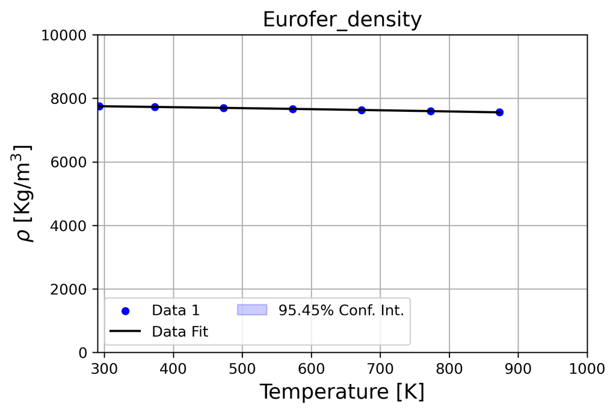

```python
material_property = 'Eurofer_density' # Load excel data for desired property name"
x_axis='Temperature [K]'
y_axis=r'$\rho$ [Kg/m$^3$]'
data_colors = ['green', 'red', 'magenta', 'blue', 'cyan', 'black']
data_labels = ['Tavassoli2004a']

load_data(excel_filename, material_property, header_rows_list=[1, 3], num_data_rows=7, room_temp=293)
display(pd.DataFrame(temp_data))

# Temperature range and initializations
T = np.arange(300, 1000, 10)
n = len(T)

print(var_names)

# Concatenate and sort data for fitting
variables = [globals()[var_name] for var_name in var_names]
vars_x = variables[::2]
vars_y = variables[1::2]
T_fit, rho_fit = concatenate_and_sort(vars_x, vars_y)
x_data_list = [x for x in vars_x]
y_data_list = vars_y
data_marker_sizes = [msize] * len(x_data_list)

fit_result = get_model_fit_and_print_it(T_fit, rho_fit, fit_func='poly', poly_deg=2,\
    material_name=material_name, property_name=material_property, eq_digits=4, print_bool=True)


custom_multi_plot(x_data_list, y_data_list, title=material_property, scale='linear', \
                  x_label=x_axis, y_label=y_axis, xlim=[290, 1000], ylim=[0, 10000],fit_line_widths=[2], \
                  legend_loc='lower left', legend_num_cols=2)

plot_fit_and_conf(T_fit, rho_fit, fit_result, sigma=2, legend=True, legend_font_size=fsize, \
                  legend_loc='lower left', legend_num_cols=2, fit_line_color='red', \
                  pred_int_fill_color='grey', conf_int_fill_color='blue')
```

### 2.2. Thermal Diffusivity

|  | EUROFER97MergiaTempK | EUROFER97MergiaThermalDiffusivityCoefcm2_s |
| --- | --- | --- |
| 0 | 295.595855 | 0.081641 |
| 1 | 322.797927 | 0.080790 |
| 2 | 373.316062 | 0.077536 |
| 3 | 472.797927 | 0.075784 |
| 4 | 573.056995 | 0.070729 |
| 5 | 673.316062 | 0.064822 |
| 6 | 772.797927 | 0.058014 |
| 7 | 873.056995 | 0.050256 |

```
['EUROFER97MergiaTempK', 'EUROFER97MergiaThermalDiffusivityCoefcm2_s']
```

**Fitting parameters for Eurofer Eurofer_diffusivity**

```
[[Model]]
    Model(<lambda>)
[[Fit Statistics]]
    # fitting method   = leastsq
    # function evals   = 16
    # data points      = 8
    # variables        = 4
    chi-square         = 2.4812e-06
    reduced chi-square = 6.2029e-07
    Akaike info crit   = -111.889799
    Bayesian info crit = -111.572033
    R-squared          = 0.99725225
[[Variables]]
    a: -3.5759e-11 +/- 6.0929e-11 (170.38%) (init = 1)
    b:  1.2037e-08 +/- 1.0716e-07 (890.27%) (init = 1)
    c: -2.8541e-05 +/- 5.9295e-05 (207.75%) (init = 1)
    d:  0.08964800 +/- 0.01017097 (11.35%) (init = 1)
[[Correlations]] (unreported correlations are < 0.100)
    C(a, b) = -0.9965
    C(b, c) = -0.9957
    C(c, d) = -0.9950
    C(a, c) = +0.9847
    C(b, d) = +0.9822
    C(a, d) = -0.9646
```

**The equation for Eurofer Eurofer_diffusivity is:**

$\displaystyle - 3.576 \cdot 10^{-11} T^{3} + 1.204 \cdot 10^{-8} T^{2} - 2.854 \cdot 10^{-5} T + 0.08965$

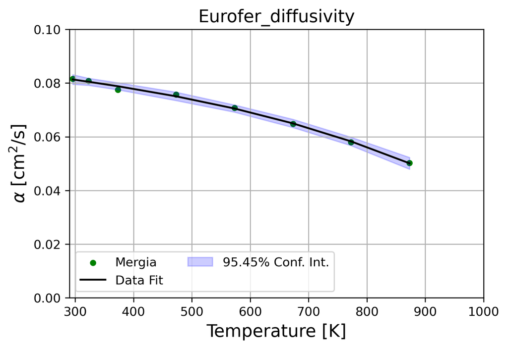

```python
material_property = 'Eurofer_diffusivity' # Load excel data for desired property name"
x_axis='Temperature [K]'
y_axis=r'$\alpha$ [cm$^2$/s]'
data_labels = ['Mergia']


load_data(excel_filename, material_property, header_rows_list=[1, 3], num_data_rows=8)
display(pd.DataFrame(temp_data))

# Temperature range and initializations
T = np.arange(300, 1000, 10)
n = len(T)

print(var_names)

# Concatenate and sort data for fitting
variables = [globals()[var_name] for var_name in var_names]
vars_x = variables[::2]
vars_y = variables[1::2]

T, Diff = concatenate_and_sort(vars_x, vars_y)

x_data_list = [x for x in vars_x]
y_data_list = vars_y
data_marker_sizes = [msize] * len(x_data_list)


fit_result = get_model_fit_and_print_it(T, Diff, fit_func='poly', poly_deg=3,\
    material_name=material_name, property_name=material_property, eq_digits=4, print_bool=True)

custom_multi_plot(x_data_list, y_data_list, title=material_property, scale='linear', \
                  data_labels=data_labels, fit_labels=None, data_colors=data_colors, \
                  fit_colors=None, data_marker_sizes=data_marker_sizes,\
                  x_label=x_axis, y_label=y_axis, xlim=[290, 1000], ylim=[0, 0.1],fit_line_widths=[2], \
                  legend_loc='lower left', legend_num_cols=2)

plot_fit_and_conf(T, Diff, fit_result, sigma=2, legend=True, legend_font_size=fsize, legend_loc='lower left', legend_num_cols=2,\
                  fit_line_color='red', pred_int_fill_color='grey', conf_int_fill_color='blue')
```

### 2.3. Specific Heat

|  | EUROFER97MergiaTempK | EUROFER97MergiaSpecificHeatJ_kgK | EUROFER97TempK1 | EUROFER97SpecificHeatJ_kgK |
| --- | --- | --- | --- | --- |
| 0 | 296.103896 | 448.395379 | 293.54795 | 454.68159 |
| 1 | 322.727273 | 461.489089 | 326.42466 | 467.34914 |
| 2 | 348.051948 | 475.353017 | 373.00000 | 488.52065 |
| 3 | 373.376623 | 485.365854 | 425.05479 | 509.65287 |
| 4 | 398.051948 | 496.148909 | 474.36986 | 522.20258 |
| 5 | 423.376623 | 504.621309 | 523.68493 | 543.35445 |
| 6 | 447.402597 | 513.863928 | 573.00000 | 551.60308 |
| 7 | 472.727273 | 521.566110 | 622.31507 | 572.75495 |
| 8 | 498.051948 | 530.038511 | 671.63014 | 585.30466 |
| 9 | 522.727273 | 536.970475 | 723.68493 | 610.73796 |
| 10 | 548.051948 | 544.672657 | 773.00000 | 653.39520 |
| 11 | 572.727273 | 550.834403 | 822.31507 | 721.85889 |
| 12 | 598.051948 | 556.996149 | 871.63014 | 803.22581 |
| 13 | 622.727273 | 565.468549 | 920.94521 | 901.79702 |
| 14 | 648.051948 | 573.170732 | 973.00000 | 1026.15505 |
| 15 | 673.376623 | 583.953787 | NaN | NaN |
| 16 | 698.051948 | 597.047497 | NaN | NaN |
| 17 | 722.727273 | 611.681643 | NaN | NaN |
| 18 | 747.402597 | 628.626444 | NaN | NaN |
| 19 | 773.376623 | 655.584082 | NaN | NaN |
| 20 | 797.402597 | 687.163030 | NaN | NaN |
| 21 | 822.727273 | 721.052632 | NaN | NaN |
| 22 | 847.402597 | 764.184852 | NaN | NaN |
| 23 | 872.727273 | 801.155327 | NaN | NaN |

```
['EUROFER97MergiaTempK', 'EUROFER97MergiaSpecificHeatJ_kgK', 'EUROFER97TempK1', 'EUROFER97SpecificHeatJ_kgK']
```

**Fitting parameters for Eurofer Eurofer_specific_heat**

```
[[Model]]
    Model(<lambda>)
[[Fit Statistics]]
    # fitting method   = leastsq
    # function evals   = 22
    # data points      = 39
    # variables        = 6
    chi-square         = 294.633164
    reduced chi-square = 8.92827769
    Akaike info crit   = 90.8646075
    Bayesian info crit = 100.845977
    R-squared          = 0.99952425
[[Variables]]
    a: -1.7427e-11 +/- 2.4494e-12 (14.06%) (init = 1)
    b:  5.6454e-08 +/- 7.7155e-09 (13.67%) (init = 1)
    c: -6.6682e-05 +/- 9.4182e-06 (14.12%) (init = 1)
    d:  0.03644199 +/- 0.00555168 (15.23%) (init = 1)
    e: -8.93190090 +/- 1.57548382 (17.64%) (init = 1)
    f:  1239.84458 +/- 171.733449 (13.85%) (init = 1)
[[Correlations]] (unreported correlations are < 0.100)
    C(a, b) = -0.9985
    C(b, c) = -0.9983
    C(c, d) = -0.9981
    C(d, e) = -0.9979
    C(e, f) = -0.9977
    C(a, c) = +0.9937
    C(b, d) = +0.9929
    C(c, e) = +0.9920
    C(d, f) = +0.9913
    C(a, d) = -0.9851
    C(b, e) = -0.9833
    C(c, f) = -0.9816
    C(a, e) = +0.9724
    C(b, f) = +0.9694
    C(a, f) = -0.9556
```

**The equation for Eurofer Eurofer_specific_heat is:**

$\displaystyle - 1.743 \cdot 10^{-11} T^{5} + 5.645 \cdot 10^{-8} T^{4} - 6.668 \cdot 10^{-5} T^{3} + 0.03644 T^{2} - 8.932 T + 1240.0$

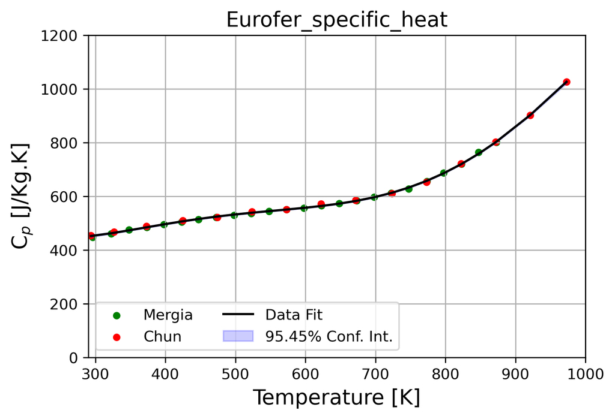

```python
material_property = 'Eurofer_specific_heat' # Load excel data for desired property name"
x_axis='Temperature [K]'
y_axis=r'C$_p$ [J/Kg.K]'
load_data(excel_filename, material_property, header_rows_list=[1, 3], num_data_rows=24)

df=pd.DataFrame(temp_data)
display(df)

# Temperature range and initializations
T = np.arange(300, 1000, 10)
n = len(T)

print(var_names)

# Concatenate and sort data for fitting
variables = [globals()[var_name] for var_name in var_names]
vars_x = variables[::2]
vars_y = variables[1::2]

T, cp = concatenate_and_sort(vars_x, vars_y)

x_data_list = [x for x in vars_x]
y_data_list = vars_y
data_marker_sizes = [msize] * len(x_data_list)
data_labels = ['Mergia','Chun']

fit_result = get_model_fit_and_print_it(T, cp, fit_func='poly', poly_deg=5,\
    material_name=material_name, property_name=material_property, eq_digits=4, print_bool=True)

custom_multi_plot(x_data_list, y_data_list, title=material_property, scale='linear', \
                  data_labels=data_labels, fit_labels=None, data_colors=data_colors, \
                  fit_colors=None, data_marker_sizes=data_marker_sizes, x_label=x_axis, \
                  y_label=y_axis, xlim=[290, 1000], ylim=[0, 1200],fit_line_widths=[2], \
                  legend_loc='lower left', legend_num_cols=2)


plot_fit_and_conf(T, cp, fit_result, sigma=2, legend=True, legend_font_size=fsize, legend_loc='lower left', legend_num_cols=2,\
                  fit_line_color='red', pred_int_fill_color='grey', conf_int_fill_color='blue')
```

```
['EUROFER97MergiaTempK', 'EUROFER97MergiaThermalConductivitykW_mK', 'EUROFER97TempC', 'EUROFER97ThermalConductivityW_mK']
```

**Fitting parameters for Eurofer Eurofer_conductivity**

```
[[Model]]
    Model(<lambda>)
[[Fit Statistics]]
    # fitting method   = leastsq
    # function evals   = 22
    # data points      = 21
    # variables        = 6
    chi-square         = 4.80457273
    reduced chi-square = 0.32030485
    Akaike info crit   = -18.9740407
    Bayesian info crit = -12.7069061
    R-squared          = 0.62382957
[[Variables]]
    a:  7.3698e-13 +/- 2.0184e-13 (27.39%) (init = 1)
    b: -1.6689e-09 +/- 4.4740e-10 (26.81%) (init = 1)
    c:  1.3676e-06 +/- 3.5886e-07 (26.24%) (init = 1)
    d: -4.8877e-04 +/- 1.2602e-04 (25.78%) (init = 1)
    e:  0.07192925 +/- 0.01817070 (25.26%) (init = 1)
    f:  26.5956161 +/- 0.75810323 (2.85%) (init = 1)
[[Correlations]] (unreported correlations are < 0.100)
    C(a, b) = -0.9948
    C(b, c) = -0.9919
    C(c, d) = -0.9869
    C(d, e) = -0.9745
    C(a, c) = +0.9741
    C(b, d) = +0.9592
    C(c, e) = +0.9284
    C(a, d) = -0.9272
    C(b, e) = -0.8795
    C(e, f) = -0.8794
    C(a, e) = +0.8339
    C(d, f) = +0.7802
    C(c, f) = -0.7065
    C(b, f) = +0.6479
    C(a, f) = -0.6006
```

**The equation for Eurofer Eurofer_conductivity is:**

$\displaystyle 7.37 \cdot 10^{-13} T^{5} - 1.669 \cdot 10^{-9} T^{4} + 1.368 \cdot 10^{-6} T^{3} - 0.0004888 T^{2} + 0.07193 T + 26.6$

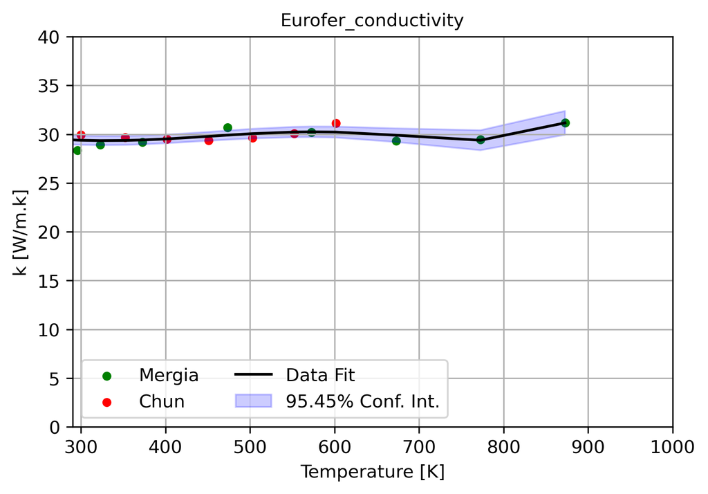

```python
# # Load excel data for desired property name
material_property = "Eurofer_conductivity"
x_axis = 'Temperature [K]'
y_axis = 'k [W/m.k]'
load_data(excel_filename, material_property, header_rows_list=[1, 3], num_data_rows=16, room_temp=293)
#Temperature range and initializations
T_fit = np.arange(300, 1000, 1)
n = len(T_fit)
print(var_names)

# Concatenate and sort data for fitting
variables = [globals()[var_name] for var_name in var_names]
vars_x = variables[::2]
vars_y = variables[1::2]

T, k = concatenate_and_sort(vars_x, vars_y)

x_data_list = [x for x in vars_x]
y_data_list = vars_y
data_colors = ['green', 'red', 'magenta', 'blue', 'cyan', 'black']
data_marker_sizes = [msize] * len(x_data_list)
data_labels = ['Mergia','Chun']

fit_result = get_model_fit_and_print_it(T, k, fit_func='poly', poly_deg=5,\
    material_name=material_name, property_name=material_property, eq_digits=4, print_bool=True)

k_fit = fit_result.eval(x=T_fit)

custom_multi_plot(x_data_list, y_data_list,
                  x_label=x_axis, y_label=y_axis, title=material_property,
                  scale='linear', font_size=fsize, xlim=[290, 1000], ylim=[0, 40],
                  grid=True, legend=True, data_labels=data_labels, fit_labels=None,
                  data_colors=data_colors, fit_colors=None, data_marker_sizes=data_marker_sizes,
                  fit_line_widths=[2], x_label_font_size=fsize, y_label_font_size=fsize, title_font_size=fsize,\
                  legend_font_size=fsize, legend_loc='lower left', legend_num_cols=2)

plot_fit_and_conf(T, k, fit_result, sigma=2, legend=True, legend_font_size=fsize, legend_loc='lower left', legend_num_cols=2,\
                  fit_line_color='red', pred_int_fill_color='grey', conf_int_fill_color='blue')
```